# Dream Team Assignment2

### Mixed Effects Model

```r
library(lme4)
popularityMixedModel_loud <- lmer(popularity ~
                             duration_min + (loudness | is_punk),
                             data = genres)
```

```
## boundary (singular) fit: see ?isSingular
```

```r
summary(popularityMixedModel_loud)
```

```
## Linear mixed model fit by REML ['lmerMod']
## Formula: popularity ~ duration_min + (loudness | is_punk)
##    Data: genres
##
## REML criterion at convergence: 21744.6
##
## Scaled residuals:
##     Min      1Q  Median      3Q     Max
## -3.6777 -0.4619  0.0755  0.6026  4.3823
##
## Random effects:
##  Groups   Name        Variance Std.Dev. Corr
##  is_punk  (Intercept) 156.813  12.523
##           loudness      1.359   1.166   1.00
##  Residual             204.649  14.306
## Number of obs: 2664, groups:  is_punk, 2
##
## Fixed effects:
##              Estimate Std. Error t value
## (Intercept)   35.6115     0.8313  42.839
## duration_min   0.9744     0.1870   5.209
##
## Correlation of Fixed Effects:
##             (Intr)
## duration_mn -0.942
## optimizer (nloptwrap) convergence code: 0 (OK)
## boundary (singular) fit: see ?isSingular
```

```r
ICC_punk <-  156.813/ (156.813 + 204.649)
ICC_punk
```

```
## [1] 0.4338298
```

### Mixed Model Visual

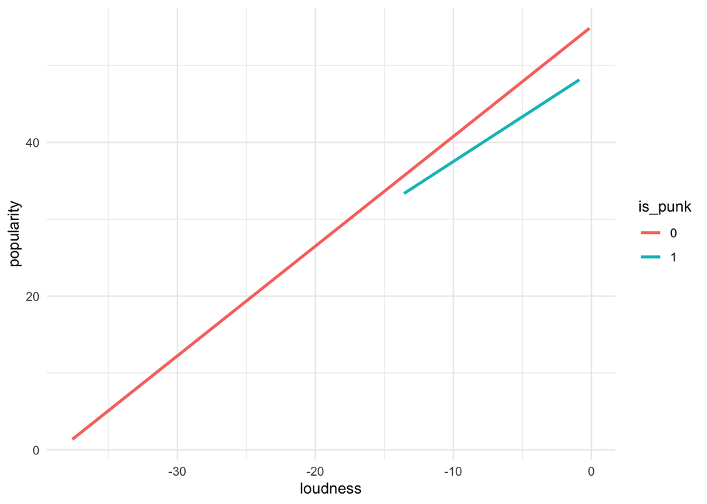

```r
genres$is_punk <- as.factor(genres$is_punk)

ggplot(genres, aes(loudness, popularity,
                              group = is_punk, color = is_punk)) +
  geom_smooth(method = "lm", se = FALSE) +
  theme_minimal()
```

### Mixed Model Results

- This mixed model resulted in a ICC larger thn 0 showing there is some variance however there is not an extreme difference with a result of .4338298 as the ICC. So again we support their is a difference between the two factors, but based on the previous linear models loudness is actually a bigger attribute for popularity in non-punk music.
- Seeing as we were explaining very little in our previous linear models we did see there is actually a lot more to explain the variance in popularity and wanted to review how the tempo and energy may effect punk music vs. the popularity of non-punk music.

```r
# Linear Regression  - Punk
punk_lm_2 <- lm(popularity ~ energy + tempo, data = punk)

summary(punk_lm_2)
```

```
##
## Call:
## lm(formula = popularity ~ energy + tempo, data = punk)
##
## Residuals:
##     Min      1Q  Median      3Q     Max
## -31.753  -5.836   0.115   5.455  26.283
##
## Coefficients:
##              Estimate Std. Error t value Pr(>|t|)
## (Intercept)  31.88272   10.11459   3.152  0.00235 **
## energy      -21.20013    9.87259  -2.147  0.03508 *
## tempo         0.19397    0.07197   2.695  0.00873 **
## ---
## Signif. codes:  0 '***' 0.001 '**' 0.01 '*' 0.05 '.' 0.1 ' ' 1
##
## Residual standard error: 8.832 on 73 degrees of freedom
## Multiple R-squared:  0.1095, Adjusted R-squared:  0.0851
## F-statistic: 4.488 on 2 and 73 DF,  p-value: 0.01451
```

```r
# Linear Regression - Not Punk
not_punk_lm_2 <- lm(popularity ~ energy + tempo, data = not_punk)

summary(not_punk_lm_2)
```

```
##
## Call:
## lm(formula = popularity ~ energy + tempo, data = not_punk)
##
## Residuals:
##     Min      1Q  Median      3Q     Max
## -53.539  -8.509   0.675   9.783  49.086
##
## Coefficients:
##             Estimate Std. Error t value Pr(>|t|)
## (Intercept) 24.47158    1.93916  12.620   <2e-16 ***
## energy      34.00891    1.37403  24.751   <2e-16 ***
## tempo       -0.02826    0.01786  -1.582    0.114
## ---
## Signif. codes:  0 '***' 0.001 '**' 0.01 '*' 0.05 '.' 0.1 ' ' 1
##
## Residual standard error: 14.33 on 2585 degrees of freedom
## Multiple R-squared:  0.2156, Adjusted R-squared:  0.215
## F-statistic: 355.2 on 2 and 2585 DF,  p-value: < 2.2e-16
```

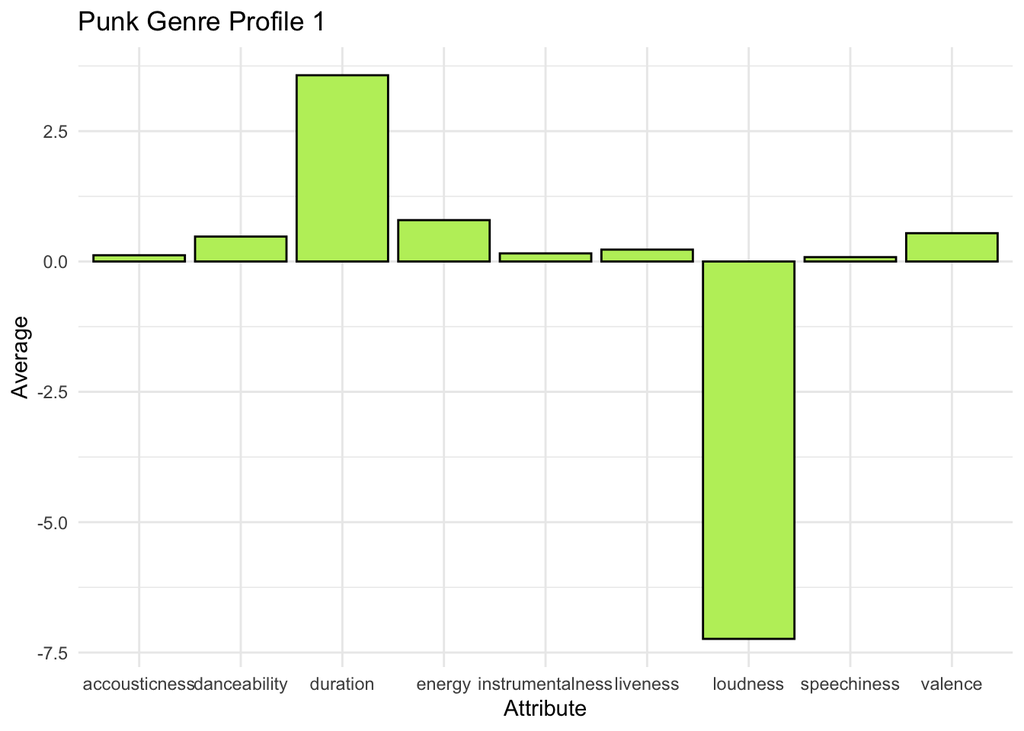

```r
punk_b1 <- punk_avg[-c(9,11),]


punk_bar <-  ggplot(data = punk_b1, aes(x = Attribute, y = Average)) +
  geom_bar(stat = 'identity', fill = 'darkolivegreen2', color = 'black') +
  theme_minimal() +
  labs(title = 'Punk Genre Profile 1')

punk_bar
```

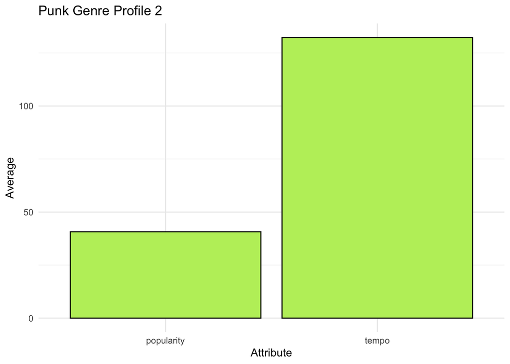

```r
punk_b2 <-  punk_avg[c(9,11),]

punk_bar2 <-  ggplot(data = punk_b2, aes(x = Attribute, y = Average)) +
  geom_bar(stat = 'identity', fill = 'darkolivegreen2', color = 'black') +
  theme_minimal() +
  labs(title = 'Punk Genre Profile 2')

punk_bar2
```